# BayArea Bike Share Slide Deck

#### This document explores a dataset containing 519700 rows and 15 columns of BikeSharing in BayArea

### Exploratory Analysis - Univariate Exploration of Data

#### Number of trips during each hour of day

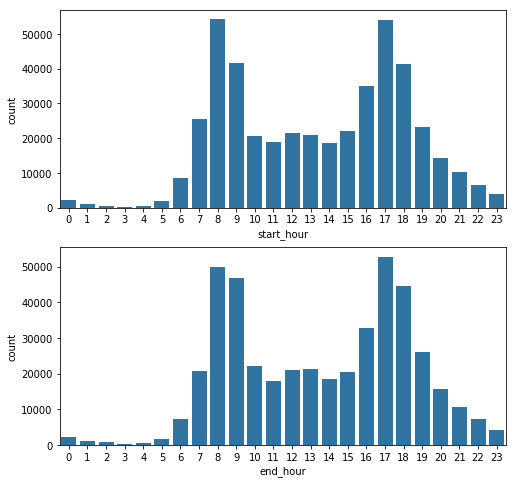

```python
fig, ax = plt.subplots(nrows=2, figsize = [8,8])

default_color = sb.color_palette()[0]
sb.countplot(data = bike_data_df, x = 'start_hour', color = default_color, ax = ax[0])

sb.countplot(data = bike_data_df, x = 'end_hour', color = default_color, ax = ax[1])

plt.show();
```

##### Group 1 : Early morning - 12 AM to 7 AM.

##### Group 2 : Morning Peak - 7 AM to 10 AM.

##### Group 3: Aftenoon - 10 AM to 4 PM.

##### Group 4 Evening Peak - 4 PM to 7 PM.

##### Group 5 Night - 7 PM to 11 PM.

### Visualising Age of the Rider

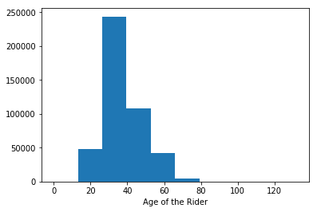

```python
plt.hist(data = bike_data_df, x = 'age_of_rider');
plt.xlabel('Age of the Rider');
```

##### Graph between number of customers and subscribers

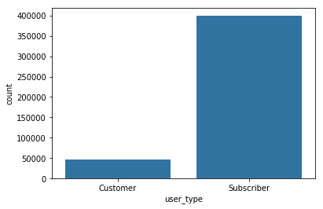

```python
base_color = sb.color_palette()[0]

sb.countplot(data=bike_data_df,x='user_type',color=base_color);
```

#### The graph shows the comparison between number of Customers versus number of Subscribers of Ford Bike Data.We can clearly see from the graph that here are more subscribers than customers for the dataset we have.

#### Graph Showing the comparison between number of bikes rented by Males versus number of number of bike rented by Female of Ford Bike Data.

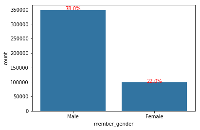

```python
# create the plot
base_color = sb.color_palette()[0]
sb.countplot(data = bike_data_df, x = 'member_gender', color = base_color)

# add annotations
n_points = bike_data_df.shape[0]
cat_counts = bike_data_df['member_gender'].value_counts()
locs, labels = plt.xticks() # get the current tick locations and labels

# loop through each pair of locations and labels
for loc, label in zip(locs, labels):

    # get the text property for the label to get the correct count
    count = cat_counts[label.get_text()]
    pct_string = '{:0.1f}%'.format(100*count/n_points)

    # print the annotation just below the top of the bar
    plt.text(loc, count-8, pct_string, ha = 'center', color = 'r')
```

##### The graph shows the comparison between number of bikes rented by Males versus number of number of bike rented by Female of Ford Bike Data. We have more males than females in the dataset with 78% Males and 22% Females.

#### Number of bike usage per weekday.

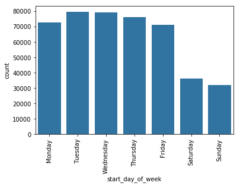

```python
level_order = ['Monday', 'Tuesday', 'Wednesday','Thursday','Friday','Saturday','Sunday']
ordered_cat = pd.api.types.CategoricalDtype(ordered = True, categories = level_order)
bike_data_df['start_day_of_week'] = bike_data_df['start_day_of_week'].astype(ordered_cat)

base_color = sb.color_palette()[0]

sb.countplot(data=bike_data_df,x='start_day_of_week',color=base_color)
plt.xticks(rotation = 90);
```

#### The graph is show the bike usage on weekdays as well as weekends. This graph shows that highest number of bikes are used on a weekday than on a weekend.

#### Top 10 busy stations for bike pickup

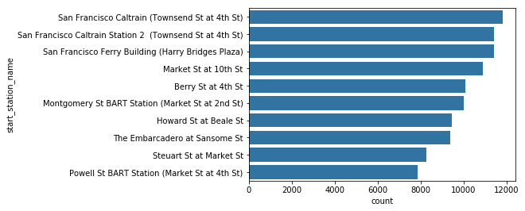

```python
base_color = sb.color_palette()[0]
start_station_name = bike_data_df['start_station_name'].value_counts()[:10].index
sb.countplot(data = bike_data_df, y = 'start_station_name', color = base_color, order = start_station_name);
```

### Bivariate Exploration - Bike Usage based on Weekday and Gender.

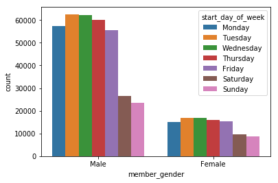

```python
sb.countplot(data = bike_data_df, x = 'member_gender', hue = 'start_day_of_week');
```

##### Bike Usage based on Weekday and Gender clearly shows that more number of males ride the bike than females and also number of bikes are used more on a weekday than on a weekend.

### Gender vs Month Bike Usage

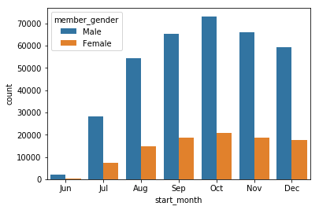

```python
level_order = ['Jun','Jul','Aug','Sep','Oct','Nov','Dec']


sb.countplot(data = bike_data_df, hue = 'member_gender', x = 'start_month',order=level_order);
```

#### Correlation Plot between Numeric Variables

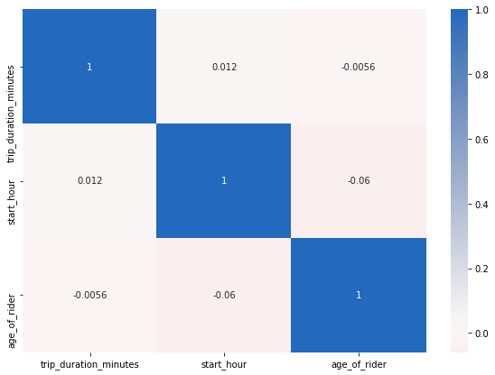

```python
# correlation plot
plt.figure(figsize = [10, 7])
sb.heatmap(bike_data_df[numeric_vars].corr(), annot = True,
           cmap = 'vlag_r', center = 0)
plt.show();
```

#### Comparison of Gender with user Type

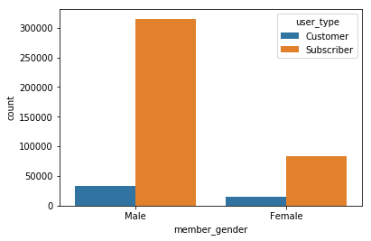

```python
sb.countplot(data = bike_data_df, x = 'member_gender', hue = 'user_type');
```

#### Below Graph showing what time of the Day is most busy and which is least?

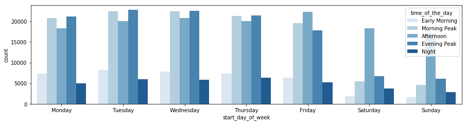

```python
plt.figure(figsize = [15, 12])

# subplot 1: color vs cut
plt.subplot(3, 1, 1)
sb.countplot(data = bike_data_df, x = 'start_day_of_week', hue = 'time_of_the_day', palette = 'Blues')

plt.show();
```

##### The graph clearly shows that weekdays are more busy than weekends and graph shows the peak hours of the day.

#### Box Plot showing age of rider on weekday.

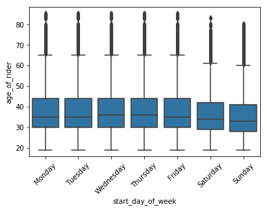

```python
base_color = sb.color_palette()[0]

sb.boxplot(data = bike_data_df, x = 'start_day_of_week', y = 'age_of_rider',color=base_color)
plt.xticks(rotation=45);
```

### Multivariate Exploration of Data

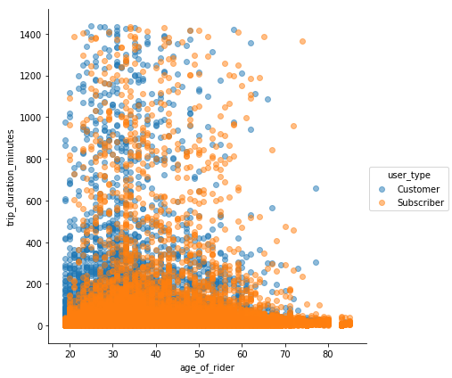

```python
g = sb.FacetGrid(data = bike_data_df, hue = 'user_type', size = 6)
g.map(plt.scatter, 'age_of_rider','trip_duration_minutes',alpha=0.5)
y_ticks = [400, 800,1200, 1600, 2000, 2400]
x_ticks = [20,30,40,50,60,70,80]
g.add_legend();
```

#### Multivariate graph between time of day, gender and age of the rider

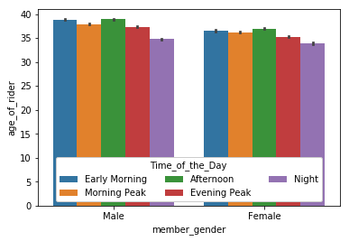

```python
ax = sb.barplot(data = bike_data_df, x = 'member_gender', y = 'age_of_rider', hue = 'time_of_the_day')
ax.legend(loc =8, ncol = 3, framealpha = 1, title = 'Time_of_the_Day');
```

##### The graph clearly depicts that the age group of male and female is same while riding a bike at any point of day even though the number of females riding a bike is less than males.

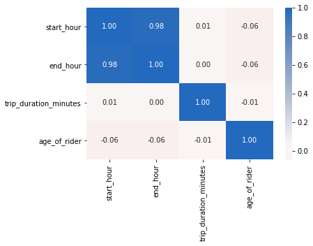

```python
sb.heatmap(bike_data_df.corr(), annot = True, fmt = '.2f', cmap = 'vlag_r', center = 0);
```

#### Exploration of two categorical variables (gender and customer type) with numerical (age)

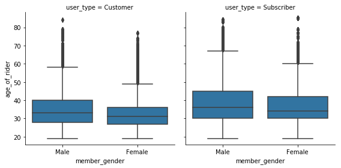

```python
g = sb.FacetGrid(data = bike_data_df, col = 'user_type', size = 4)
g.map(sb.boxplot, 'member_gender', 'age_of_rider');
```